# DA3-A1

## Parameters Selection

Initial checking of various parameters to try based on intuition, to see which parameters can affect the wage.

```r
df = df[, c('weight','earnwke', 'uhours', 'race', 'age', 'sex', 'marital','grade92', 'state','class','prcitshp')]
```

## Creating variable of interest: Hourly Wage

```r
df$HourlyWage = round(df$earnwke/df$uhours)
```

## Parameters Selection:

Analyzing the different parameters initially chosen

## Weight

```r
weight_summary <- summary(df$weight)
weight_summary
```

```
##    Min. 1st Qu.  Median    Mean 3rd Qu.    Max.
##   222.1  1054.6  2769.5  2375.1  3427.1  7469.4
```

```r
## Min. 1st Qu.  Median    Mean   3rd Qu.    Max.
## 222.1  1054.6  2769.5  2375.1  3427.1  7469.4
```

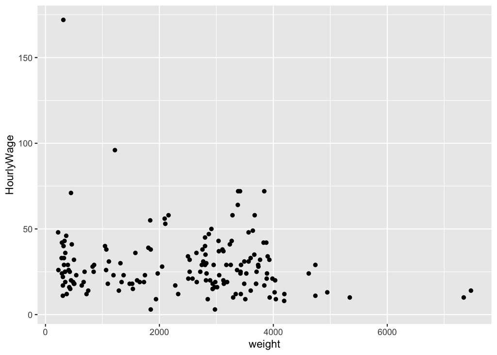

```r
## Check weight graph
 ggplot(df, aes(x=weight, y=HourlyWage)) + geom_point()
```

Visualization shows a random spread.

```r
## Tried using Pearson Coefficient to see best fit for the various parameters
## https://statistics.laerd.com/statistical-guides/pearson-correlation-coefficient-statistical-guide.php
## https://libguides.library.kent.edu/spss/pearsoncorr
## used the guideline here to interpret the Pearson's correlation coefficient
## okay to try, since weight is continuous parameter
## tried the code chunk from https://www.reneshbedre.com/blog/correlation-analysis-r.html
cor(df$HourlyWage, df$weight, method = 'pearson')
```

```
## [1] -0.1220714
```

```r
## -0.1220714
```

Here, we can see using the pearson correlation that the weight has very low negative correlation to the hourly wage. So, it will not be considered as a predictor parameter.

## Race

```r
unique(df$race)
```

```
## [1]  1  8  2  4  7 15
```

Converting the race variable to categorical variable.

```r
df$race = as.factor(df$race)
```

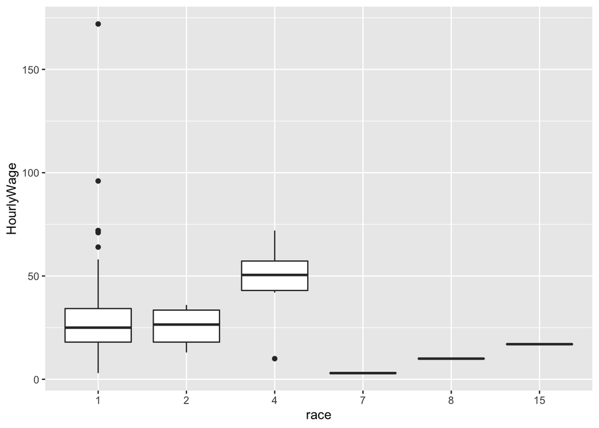

```r
race_box <- ggplot(df, aes(x=race, y=HourlyWage)) +
  geom_boxplot()
race_box
```

```r
## https://www.scribbr.com/statistics/anova-in-r/
## since category
Anova_Race <- aov(HourlyWage ~ race, data = df)

summary(Anova_Race)
```

```
##              Df Sum Sq Mean Sq F value Pr(>F)
## race          5   3252   650.3   1.899 0.0974 .
## Residuals   157  53761   342.4
## ---
## Signif. codes:  0 '***' 0.001 '**' 0.01 '*' 0.05 '.' 0.1 ' ' 1
```

```r
## Df Sum Sq Mean Sq F value Pr(>F)
## race          5   3252   650.3   1.899 0.0974 .
## Residuals   157  53761   342.4
## ---
## Signif. codes:  0 ‘***’ 0.001 ‘**’ 0.01 ‘*’ 0.05 ‘.’ 0.1 ‘ ’ 1
```

## Age

```r
age_summary <- summary(df$age)
age_summary
```

```
##    Min. 1st Qu.  Median    Mean 3rd Qu.    Max.
##    16.0    29.0    40.0    40.2    50.0    64.0
```

```r
## Min. 1st Qu.  Median    Mean 3rd Qu.    Max.
##   16.0    29.0    40.0    40.2    50.0    64.0
```

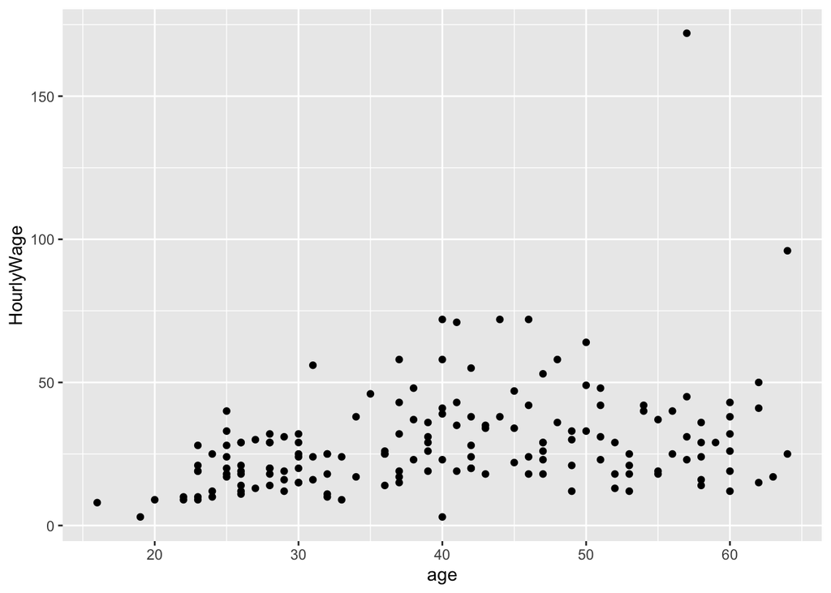

```r
age_plot <- ggplot(df, aes(x=age, y=HourlyWage)) + geom_point()
age_plot
```

Looking at the age_plot, we can see that maybe there is a minor trend of increase in hourly wage with increase in age

```r
cor(df$HourlyWage, df$age, method = 'pearson')
```

```
## [1] 0.3285981
```

```r
## [1] 0.3285981
```

Looking at the correlation test, we can see that there a light positive correlation, so we can keep this parameter.

## Sex

```r
unique(df$sex)
```

```
## [1] 1 2
```

Converting the race variable to categorical variable.

```r
df$sex = as.factor(df$sex)
```

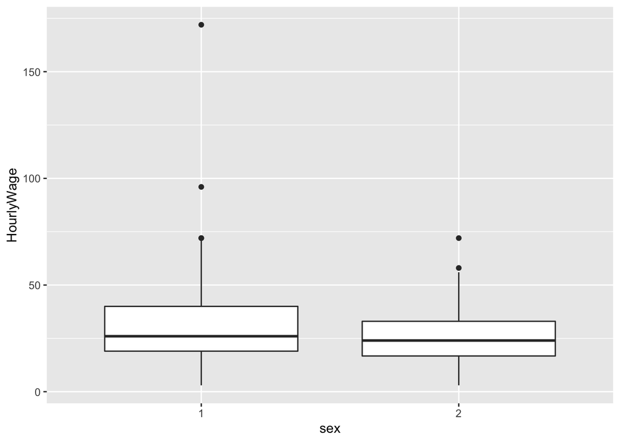

```r
ggplot(df, aes(x=sex, y=HourlyWage)) +
  geom_boxplot()
```

There eems to be difference in pay based on the sex

```r
Anova_Sex <- aov(HourlyWage ~ sex, data = df)
summary(Anova_Sex)
```

```
##              Df Sum Sq Mean Sq F value Pr(>F)
## sex           1   1846  1846.0   5.387 0.0215 *
## Residuals   161  55167   342.6
## ---
## Signif. codes:  0 '***' 0.001 '**' 0.01 '*' 0.05 '.' 0.1 ' ' 1
```

```r
#3 #Df Sum Sq Mean Sq F value Pr(>F)
## sex           1   1846  1846.0   5.387 0.0215 *
## Residuals   161  55167   342.6
## ---
##Signif. codes:  0 ‘***’ 0.001 ‘**’ 0.01 ‘*’ 0.05 ‘.’ 0.1 ‘ ’ 1
```

## Marital

```r
unique(df$marital)
```

```
## [1] 7 3 1 5 4 6
```

Converting the marital variable to categorical variable.

```r
df$marital = as.factor(df$marital)
```

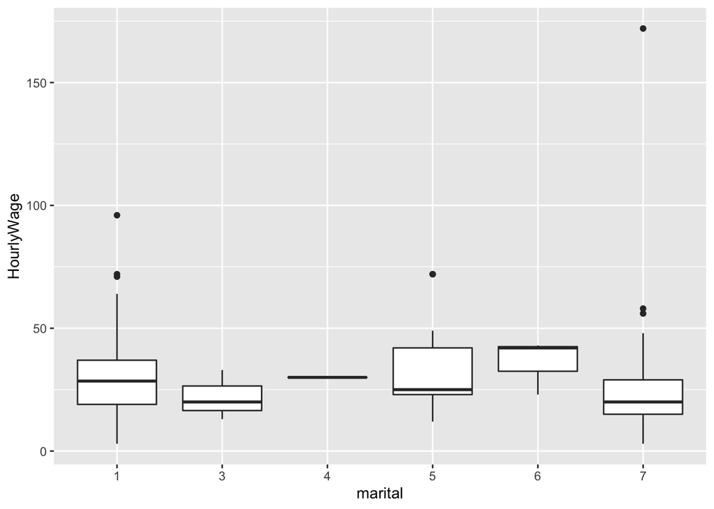

```r
marital_box <- ggplot(df, aes(x = marital, y = HourlyWage)) +
  geom_boxplot()

marital_box
```

```r
Anova_Marital<- aov(HourlyWage ~ marital, data = df)

summary(Anova_Marital)
```

```
##              Df Sum Sq Mean Sq F value Pr(>F)
## marital       5   1275   254.9   0.718  0.611
## Residuals   157  55738   355.0
```

```r
##              Df Sum Sq Mean Sq F value Pr(>F)
## marital       5   1275   254.9   0.718  0.611
## Residuals   157  55738   355.0
```

The Marital parameter has a large p-value so it will not be used as a predictor.

## Grade

```r
unique(df$grade92)
```

```
##  [1] 43 44 42 36 34 40 39 46 41 33
```

Converting the grade variable to categorical variable.

```r
df$grade92 = as.factor(df$grade92)
```

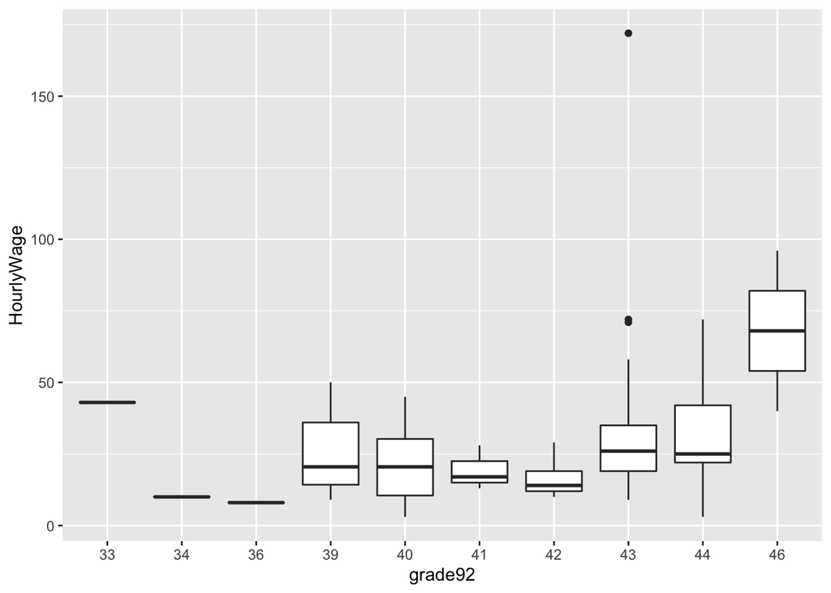

```r
grade_box <- ggplot(df, aes(x = grade92, y = HourlyWage)) +
  geom_boxplot()
grade_box
```

In the grade_box plot, we can see the it seems like there’s a good relationship.

```r
Anova_grade92<- aov(HourlyWage ~ grade92, data = df)

summary(Anova_grade92)
```

```
##              Df Sum Sq Mean Sq F value Pr(>F)
## grade92       9   7075   786.1   2.408 0.0139 *
## Residuals   153  49938   326.4
## ---
## Signif. codes:  0 '***' 0.001 '**' 0.01 '*' 0.05 '.' 0.1 ' ' 1
```

```r
## Df Sum Sq Mean Sq F value Pr(>F)
## grade92       9   7075   786.1   2.408 0.0139 *
## Residuals   153  49938   326.4
## Signif. codes:  0 ‘***’ 0.001 ‘**’ 0.01 ‘*’ 0.05 ‘.’ 0.1 ‘ ’ 1
```

The ANOVA test shows that hourly wage and grade92 have a significant relation. So grade92 parameter will be used as a predictor.

## Class

```r
unique(df$class)
```

```
## [1] "Private, For Profit"  "Private, Nonprofit"   "Government - Local"
## [4] "Government - Federal" "Government - State"
```

```r
## [1] "Private, For Profit"  "Private, Nonprofit"   "Government - Local"   "Government - Federal"
## [5] "Government - State"
```

Converting the class variable to categorical variable.

```r
df$class = as.factor(df$class)
```

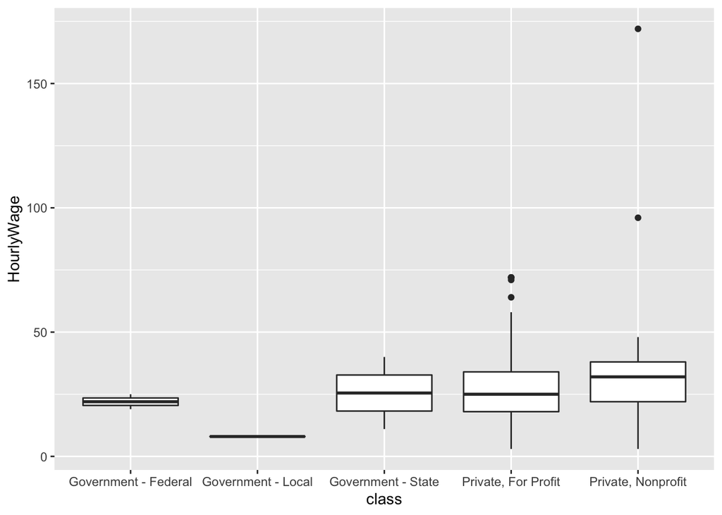

```r
class_box <- ggplot(df, aes(x = class, y = HourlyWage)) +
  geom_boxplot()
class_box
```

The class_box plot showed that the there seems to be a relationship with this parameter

```r
Anova_class <- aov(HourlyWage ~ class, data = df)

summary(Anova_class)
```

```
##              Df Sum Sq Mean Sq F value Pr(>F)
## class         4   2952   738.0   2.157 0.0763 .
## Residuals   158  54061   342.2
## ---
## Signif. codes:  0 '***' 0.001 '**' 0.01 '*' 0.05 '.' 0.1 ' ' 1
```

```r
## Df Sum Sq Mean Sq F value Pr(>F)
## class         4   2952   738.0   2.157 0.0763 .
## Residuals   158  54061   342.2
## ---
## ignif. codes:  0 ‘***’ 0.001 ‘**’ 0.01 ‘*’ 0.05 ‘.’ 0.1 ‘ ’ 1
```

## Prcitshp

```r
unique(df$prcitshp)
```

```
## [1] "Native, Born Abroad Of US Parent(s)"
## [2] "Native, Born In US"
## [3] "Foreign Born, Not a US Citizen"
## [4] "Foreign Born, US Cit By Naturalization"
```

```r
##Native, Born Abroad Of US Parent(s)"    "Native, Born In US"
##[3] "Foreign Born, Not a US Citizen"         "Foreign Born, US Cit By Naturalization"
```

```r
df$prcitshp = as.factor(df$prcitshp)
```

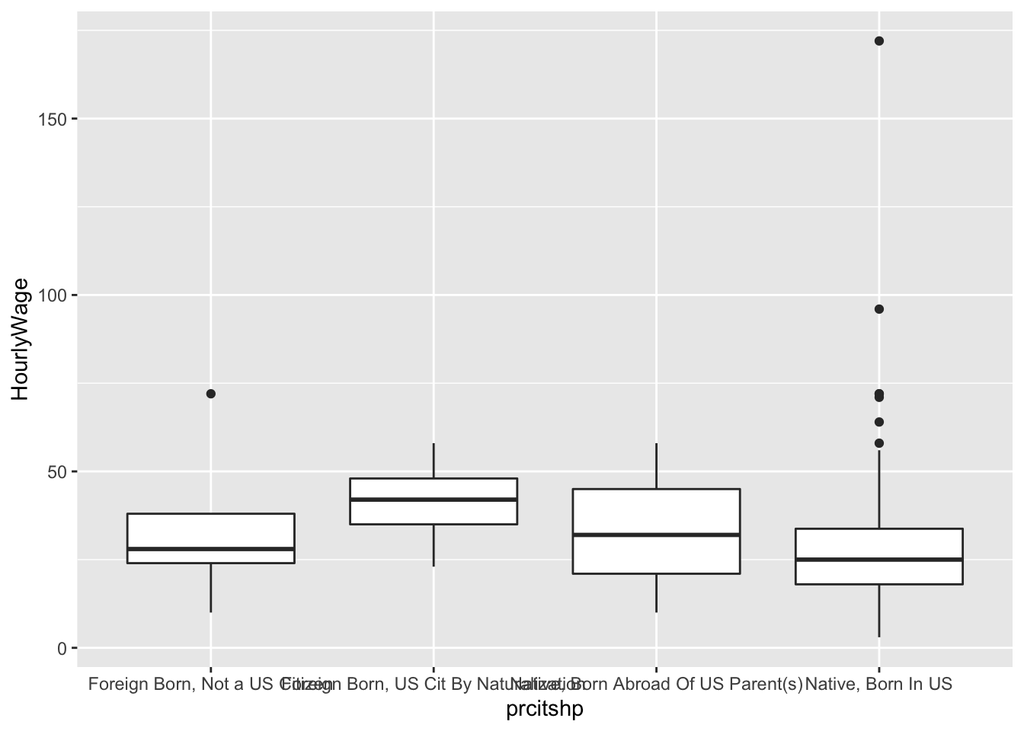

```r
ggplot(df, aes(x = prcitshp, y = HourlyWage)) +
  geom_boxplot()
```

```r
Anova_prcitshp <- aov(HourlyWage ~ prcitshp, data = df)

summary(Anova_prcitshp)
```

```
##              Df Sum Sq Mean Sq F value Pr(>F)
## prcitshp      3   1047     349   0.991  0.398
## Residuals   159  55966     352
```

The prcitshp parameter will not used as predictor based on the results above.

## Formulas

```r
Formula1 = as.formula(HourlyWage~age)
Formula2 = as.formula(HourlyWage~age+race)
Formula3 = as.formula(HourlyWage~age+race+grade92)
Formula4 = as.formula(HourlyWage~age+race+grade92+sex+class)
```

## Training the model

```r
Model1 = lm(Formula1,df)
Model2 = lm(Formula2,df)
Model3 = lm(Formula3,df)
Model4 = lm(Formula4,df)
```

## RMSE Calculation

```r
df$PredictM1 = predict(Model1,df)
RMSE1 = accuracy(df$PredictM1,df$HourlyWage)[2]

df$PredictM2 = predict(Model1,df)
RMSE2 = accuracy(df$PredictM2,df$HourlyWage)[2]

df$PredictM3 = predict(Model3,df)
RMSE3 = accuracy(df$PredictM3,df$HourlyWage)[2]

df$PredictM4 = predict(Model4,df)
RMSE4 = accuracy(df$PredictM4,df$HourlyWage)[2]
```

## BIC results of each model

```r
Bic1 = BIC(Model1)
Bic2 = BIC(Model2)
Bic3 = BIC(Model3)
Bic4 = BIC(Model4)
```

```r
Results = data.frame(Model = c("Model 1","Model 2","Model 3","Model 4"),
                     RMSE = c(RMSE1,RMSE2,RMSE3,RMSE4),
                     BIC =c(Bic1,Bic2,Bic3,Bic4))

Results
```

```
##     Model     RMSE      BIC
## 1 Model 1 17.66360 1413.966
## 2 Model 2 17.66360 1430.721
## 3 Model 3 16.43012 1461.680
## 4 Model 4 15.44986 1462.000
```

Based on RMSE, model4 is best. However, model1 has the lowest BIC so it could be used for predicting the hourly wage.

## Cross-validation

### cross fold validation with 5 folds

```r
train.control <- trainControl(method = "cv", number = 5)
```

## Model Training - Cross Validation

```r
Model11 <- train(Formula1, data = df, method = "lm",
               trControl = train.control)

Model22 <- train(Formula2, data = df, method = "lm",
                 trControl = train.control)

Model33 <- train(Formula3, data = df, method = "lm",
                 trControl = train.control)

Model44 <- train(Formula4, data = df, method = "lm",
                 trControl = train.control)
```

```r
RMSE = data.frame(Resample = c('Fold 1','Fold 2','Fold 3','Fold 4','Fold 5','Average'),
                  Model1 = c(Model11$resample$RMSE,mean(Model11$resample$RMSE)),
                  Model2 = c(Model22$resample$RMSE,mean(Model22$resample$RMSE)),
                  Model3 = c(Model33$resample$RMSE,mean(Model33$resample$RMSE)),
                  Model4 = c(Model44$resample$RMSE,mean(Model44$resample$RMSE))
                  )
RMSE
```

```
##   Resample   Model1   Model2   Model3   Model4
## 1   Fold 1 14.02994 13.41153 16.06990 15.97381
## 2   Fold 2 16.61066 13.37736 15.70441 15.69640
## 3   Fold 3 26.65427 29.04244 12.00348 26.67958
## 4   Fold 4 16.92721 13.94967 26.94005 12.07307
## 5   Fold 5 11.95179 12.65704 16.66580 16.48664
## 6  Average 17.23477 16.48761 17.47673 17.38190
```

The cross validation shows that model2 has the lowest RMSE and it should be used for predicting the parameter of interest.